# Lung Survival Example

Garrett Miller

# Introduction

The purpose of this report is to summarize the results from an analysis on the NCCTG Lung cancer data set ([documentation](https://stat.ethz.ch/R-manual/R-devel/library/survival/html/lung.html)). The dataset contains survival information on patients with advanced lung cancer from the North Central Cancer Treatment group and can be found in the *survival* package.

# Variables

- inst: Institution code
- time: Survival time in days
- status: censoring status 1=censored, 2=dead
- age: Age in years
- sex: Male=1 Female=2
- ph.ecog: ECOG performance score as rated by the physician. 0=asymptomatic, 1= symptomatic but completely ambulatory, 2= in bed <50% of the day, 3= in bed > 50% of the day but not bedbound, 4 = bedbound
- ph.karno: Karnofsky performance score (bad=0-good=100) rated by physician
- pat.karno: Karnofsky performance score as rated by patient
- meal.cal: Calories consumed at meals
- wt.loss: Weight loss in last six months (pounds)

# Methods

Data were examined for missing values, but no missing values were imputed. Confidence intervals are based on an alpha on 0.05. Performance score variables (ph.ecog, ph.karno, pat.karno), were treated as ordinal factor variables, since the scores are discrete values. Age, wt.loss, and meal.cal were considered as continuous variables. Histograms and scatterplots were used to summarize variables of interest. Kaplan-Meier curves were used to compare survival between males and females. Cox proportional hazards models (coxPH) were used to obtain hazard ratios on variables on interest. In addition, the coxPH models were used to determine a test statistic equivalent to the log-rank test, as the log-rank test was unavailable for survival models that accounted for left-truncation. The models were checked to meet the proportional hazards assumption. All analyses were performed in R (4.2.2).

# Data

```r
# Loading survival data from survival package
data(lung, package="survival")
dd_raw <- get(data("lung"))

# Getting the dimensions of the data
(dim(dd_raw))
```

```
## [1] 228  10
```

```r
# Data prep/cleaning ----
dd <-  dd_raw %>%
  # Reducing status to 0/1 from 1/2
  mutate(across(status , ~. - 1)) %>%
  # Setting levels of ph.ecog variable
  mutate(across(ph.ecog, ~factor(., levels = c(0:4)))) %>%
  # Setting levels of ph.karno variable
  mutate(across(ph.karno, ~factor(., levels = seq(50, 100, 10)))) %>%
  # Setting levels of pat.karno variable
  mutate(across(pat.karno, ~factor(., levels = seq(30, 100, 10)))) %>%
  # Converting sex to factor, keeping as 1/2
  mutate(across(sex, ~factor(as.character(.), levels = c(1, 2),
                             labels = c("Male", "Female")))) %>%
  # Make survival time in the same units as age, to include age in
  # survival analysis accounting for left-truncation
  mutate(across(time, ~./365.25))


# Defining continuous variables
cont_demo_vars <- c(
  "age",
  "meal.cal",
  "wt.loss"
)

# Defining categorical variables
cat_demo_vars <- c(
  "ph.karno",
  "ph.ecog",
  "pat.karno",
  "sex"
  )

# Defining Performance Metrics
perform_metrics <- c(
  "ph.ecog",
  "ph.karno",
  "pat.karno"
)

# Defining performance metric variables
perform_metrics <- c("ph.ecog",
                     "ph.karno",
                     "pat.karno")
```

# Results

## Exploratory Analysis

The demographic variables were plotted by sex and survival/censoring status.

```r
## Examine presence of missing values
n_nas <- data.frame(
  do.call('rbind', apply(dd, 2, function(x){table(is.na(x))}))
)

names(n_nas) <- c("Non-Missing", "Missing")

# Output NAs as a table
n_nas %>%
  kable(format = 'latex') %>%
  kable_styling ()
```

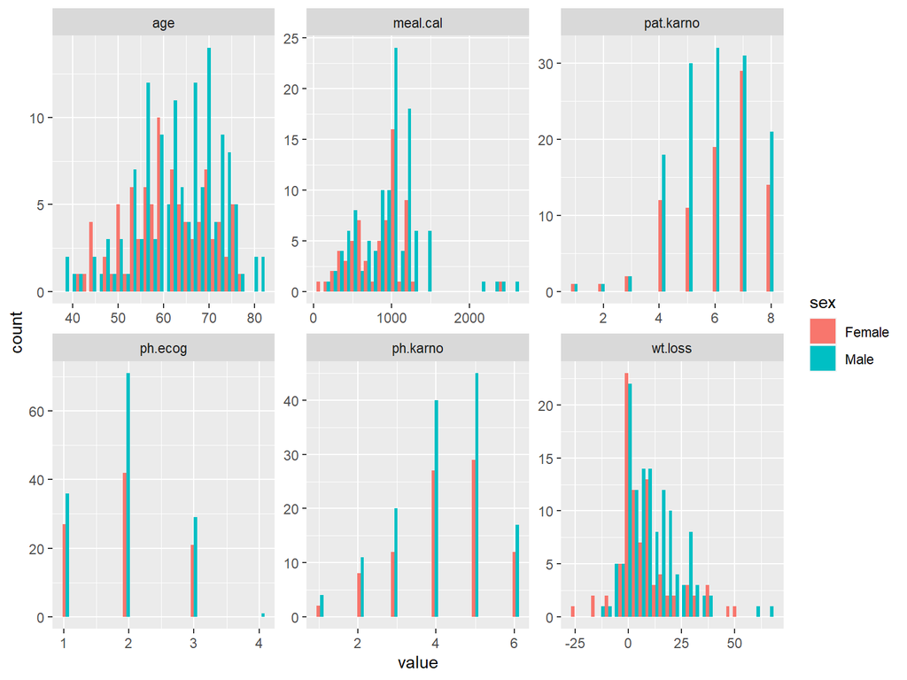

```r
# Creating boxplot to examine distributions of variables,
dd %>%
  select(sex, all_of(cont_demo_vars),
         all_of(cat_demo_vars)) %>%
  # Converting sex to character
  mutate(across(sex ,as.character)) %>%
  # Converting other variables to numeric
  mutate(across(age:pat.karno, as.numeric)) %>%
  # Making data long to use facet wrap
  pivot_longer(names(.)[-1]) %>%
  # Passing to ggplot
  ggplot(aes(x = value, fill = sex, group = sex)) +
  geom_histogram(position = 'dodge') +
  facet_wrap(. ~ name, scales = 'free')
```

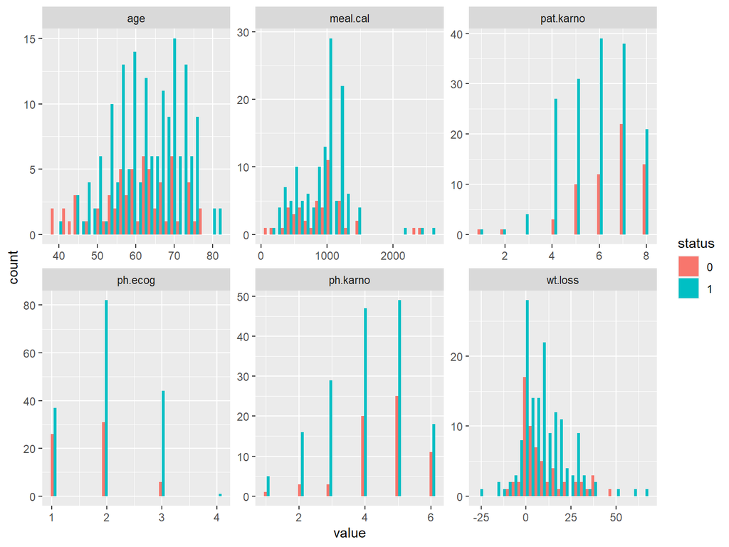

```r
# Plotting demographic and score variables by survival status
dd %>%
  select(status, all_of(cont_demo_vars),
         all_of(cat_demo_vars)) %>%
  select(-sex) %>%
  mutate(across(status ,as.character)) %>%
  mutate(across(age:pat.karno, as.numeric)) %>%
  pivot_longer(names(.)[-1]) %>%
  ggplot(aes(x = value, fill = status, group = status)) +
  geom_histogram(position = 'dodge') +
  facet_wrap(. ~ name, scales = 'free')
```

## Determining differences between males and females

```r
# Looping over continuous variables, using t.test to determine
# if there is a difference between males and females in these variables
t_test_ls <- lapply(cont_demo_vars, function(var){
  test_dd <- dd %>%
    select(sex, out = one_of(var))

  res <- t.test(out ~ sex, data = test_dd, paired= FALSE)
  dat <- data.frame(
    var = var,
    p_val = round(res$p.value, 3)
  )
  row.names(dat) <- NULL
  dat
})

# Combining list into dataframe
test_dd <- do.call('rbind', t_test_ls)

test_dd %>%
  kable(format = 'html') %>%
  kable_styling(position = 'center')
```

| var | p_val |
| --- | --- |
| age | 0.064 |
| meal.cal | 0.020 |
| wt.loss | 0.060 |

```r
# Using chi-squared test to determine if there are differences between males/females
# in these variables
chi_sq_metric_by_sex <- lapply(perform_metrics, function(metric) {

  tab <- dd %>%
    select(sex, all_of(metric)) %>%
    mutate(across(all_of(metric), factor)) %>%
    group_by_at(names(.)) %>%
    dplyr::summarise(n = n()) %>%
    filter(!is.na(get(metric))) %>%
    spread(sex, n, fill = 0) %>%
    as.data.frame()


  row.names(tab) <- as.character(tab[, 1])
  tab[, 1] <- NULL

  res <- chisq.test(tab)
  data.frame(
    var = metric,
    p_val = round(res$p.value, 3)
  )

})


# Combining list into dataframe
chi_sq_metric_by_sex_dd <- do.call('rbind', chi_sq_metric_by_sex)

chi_sq_metric_by_sex_dd %>%
  kable(format = 'html') %>%
  kable_styling(position = 'center')
```

| var | p_val |
| --- | --- |
| ph.ecog | 0.721 |
| ph.karno | 0.998 |
| pat.karno | 0.636 |

```r
chi_sq_metric_by_status <- lapply(perform_metrics, function(metric) {

  tab <- dd %>%
    select(status, all_of(metric)) %>%
    mutate(across(all_of(metric), factor)) %>%
    group_by_at(names(.)) %>%
    dplyr::summarise(n = n()) %>%
    filter(!is.na(get(metric))) %>%
    spread(status, n, fill = 0) %>%
    as.data.frame()

  row.names(tab) <- as.character(tab[, 1])
  tab[, 1] <- NULL

  res <- chisq.test(tab)
  data.frame(
    var = metric,
    p_val = round(res$p.value, 3)
  )

})

chi_sq_metric_by_status_dd <- do.call("rbind", chi_sq_metric_by_status)

chi_sq_metric_by_status_dd %>%
  kable(format = 'html') %>%
  kable_styling(position = 'center')
```

| var | p_val |
| --- | --- |
| ph.ecog | 0.006 |
| ph.karno | 0.072 |
| pat.karno | 0.076 |

Fairly even distributions across continuous variables between sex. If anything, age, meal.cal, and wt.loss have some difference between groups, but these seem to make some intuitive sense

## Unique Combinations of ph.ecog and ph.karno

```r
sum_mat <- dd_raw %>%
  group_by(ph.ecog, ph.karno) %>%
  dplyr::summarise(n = n())

unique_combinations <-   sum_mat %>%
  filter(n > 0) %>%
  arrange(desc(n))

dat <- dd %>%
  select(ph.ecog, ph.karno) %>%
  na.omit()

unique_combinations %>%
  kable(format = 'latex')
```

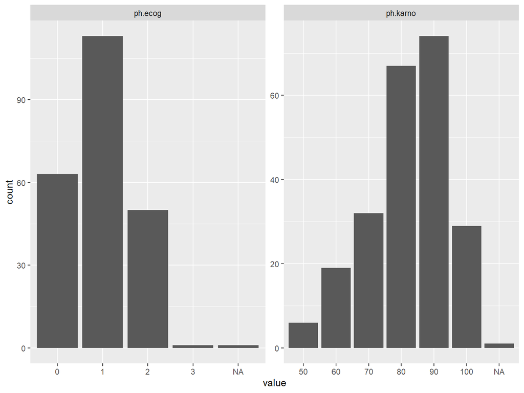

```r
# Determine spearman rank correlation coefficient between the two variables
cor_val <- cor(as.numeric(dat$ph.ecog), as.numeric(dat$ph.karno),
               method = 'spearman')

# Plot ph.ecog and ph.karno as a scatterplot with correlation coefficient
q1_plot <- dd %>%
  select(ph.ecog, ph.karno) %>%
  ggplot(aes(x = ph.ecog, y = ph.karno)) +
  geom_point(position = position_jitter(width = .1, height = 1)) +
  geom_label(x = "3", y = "100", label = round(cor_val ,2))

# Creating barplot comparing overall distribution of the two measures
dd %>%
  select(sex, ph.karno, ph.ecog) %>%
  pivot_longer(names(.)[-1]) %>%
  ggplot(aes(x = value)) +
  geom_histogram(stat = 'count') +
  facet_wrap(. ~ name, scales = 'free')
```

There were 16 unique combinations of *ph.karno* and *ph.ecog* in the data. This includes 1 case(s) where *ph.karno* was *NA* and *ph.ecog* was not, as well as 1 case(s) where *ph.ecog* was *NA* and *ph.karno* was not.

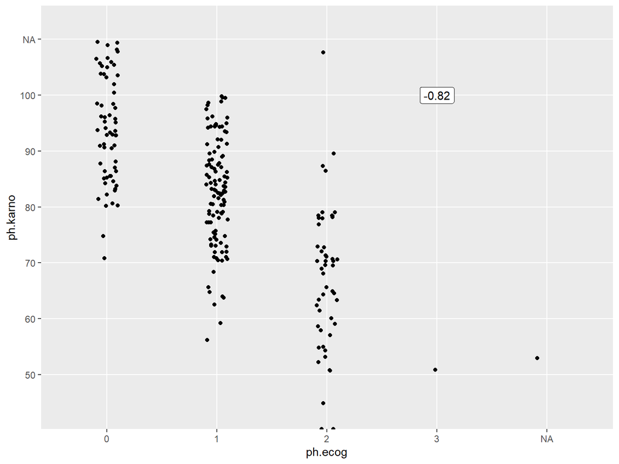

```r
q1_plot
```

Based on the scatter plot of ph.karno compared to ph.ecog, there seems to be a fair level of agreement between ph.karno and ph.ecog. A spearman correlation of -0.8183149 shows a reasonable level of agreement between the two score scales. Those that were considered “asymptomatic” in the karnofsky scale fell mainly in the 90-100 score range for ph.karno. Both scores would indicate “good” scores.

## Agreement between physician and rater

An analysis was performed to determine whether the patient recorded performance score and the physician score were related in the Karnofsky scale.

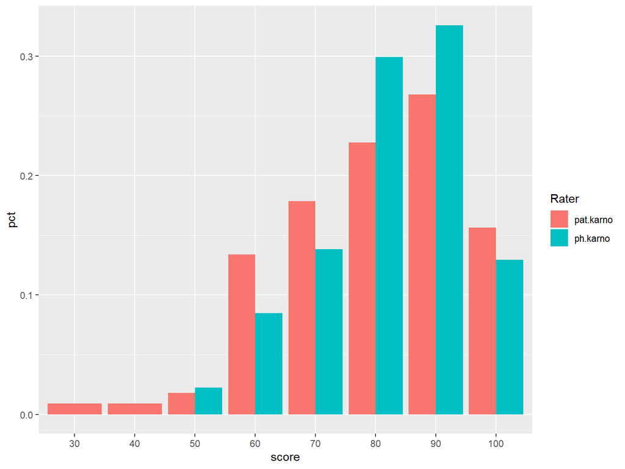

```r
### Looking at agreement between patient and physician ----
cont_tab <- dd %>%
  # Creating pseudo_id to use in pivot_wider
  mutate(id = 1:n()) %>%
  # selecting variables of interest
  select(id, ph.karno, pat.karno) %>%
  pivot_longer(names(.)[-1]) %>%
  filter(!is.na(value)) %>%
  # Setting overall factor level for both scores
  mutate(value = factor(value, seq(30, 100, 10))) %>%
  pivot_wider() %>%
  # Removing NAs
  na.omit()

# Plotting patient and physician scores as histogram
karno_bar_plot <- cont_tab %>%
  # Making long to summarize by variable
  pivot_longer(names(.)[-1]) %>%
  group_by(name, value) %>%
  # calculating count by group
  dplyr::summarise(n = n()) %>%
  ungroup() %>%
  group_by(name) %>%
  # calculating percentage by group
  mutate(pct = n/sum(n)) %>%
  # passing to ggplot
  ggplot(aes(x = value, y = pct, fill = name)) +
  geom_histogram(stat = 'identity', position = 'dodge') +
  # Adding labels
  xlab('score') +
  scale_fill_discrete('Rater')

# Calculating spearman rank correlation coefficient between patient and physician
cor_val <- cor(as.numeric(cont_tab$ph.karno),
           as.numeric(cont_tab$pat.karno),
           method = 'spearman')

# Plotting measures as a scatterplot, with correlation coefficient
corr_plot <- dd %>%
  ggplot(aes(x = ph.karno,
             y = pat.karno)) +
  geom_point(position = position_jitter(width = 0.5, height = 0.5)) +
  geom_text(x = "50", y = "40", color = 'red', label = round(cor_val, 2)) +
  ggtitle("Patient vs. Physician Karnofsky score")


karno_bar_plot
```

The bar plot shows that the patient had generally lower values for themselves, compared to the physician score. While the mode for both scores was still 90, the patient scores had some observations below 50 and the minimum of the physician score was 50. It is possible that patients in general had lower perception of their own performance, compared to a physician assessment.

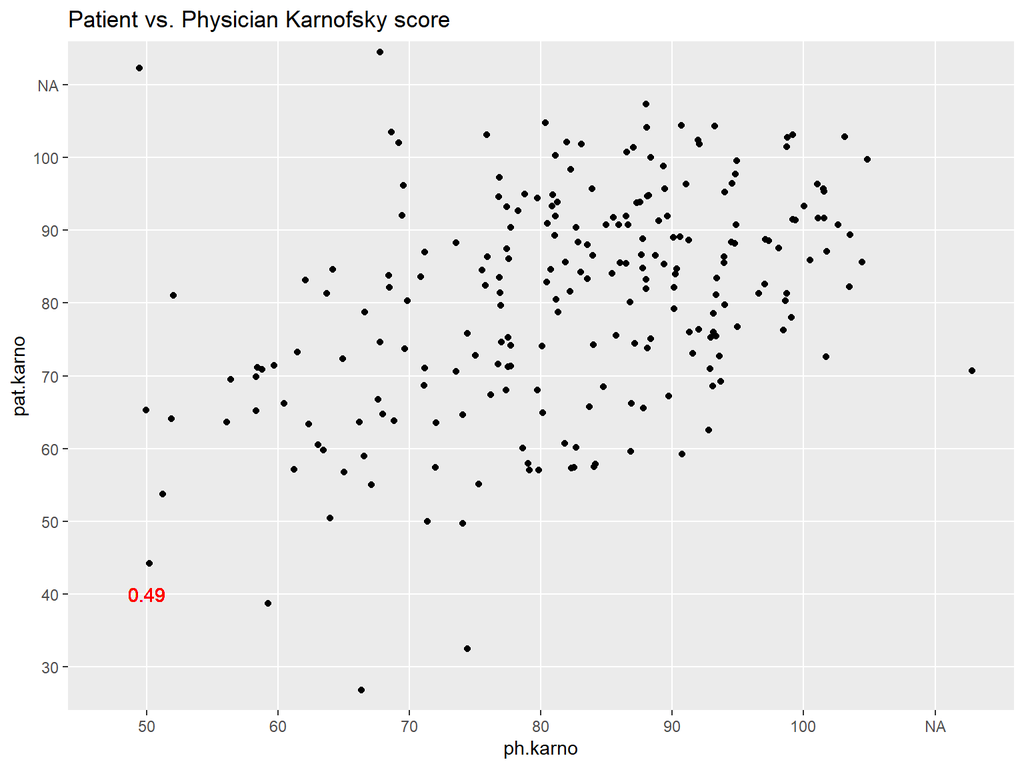

```r
corr_plot
```

The correlation between physician and patient Karnofsky score was 0.49. Since this correlation is relatively low, it would be interesting to determine whether the physician or patient score was more closely related to survival.

# Survival Analysis

## Survival Stratified by sex

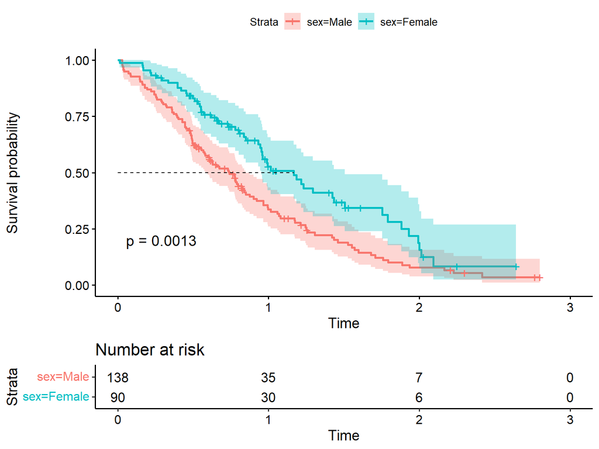

```r
# Fitting original model, non-stratified and without left truncation
fit_overall <- survfit(Surv(time, status) ~ 1, data = dd)

# Fitting original model, stratified and without left truncation
fit_0 <- survfit(Surv(time , status) ~ sex,
                 data = dd)

# Using ggsurvplot to plot Kaplan Meier curves for model without left truncation
kap_plot_no_lt <- ggsurvplot(fit_0,
                             data = dd,
                             conf.int = TRUE,
                             risk.table = TRUE,
                             pval = TRUE,
                             surv.median.line = 'h')

kap_plot_no_lt
```

```r
# Getting the median survival times from the survival model summary tables
sum_overall <- data.frame(t(summary(fit_overall)$table))
sum_grps <- data.frame(summary(fit_0)$table)

# Combining into a table
sum_both <- rbind(sum_overall, sum_grps)

### Median survival times ----
med_table <- data.frame(
  group = c("Overall", row.names(sum_grps)),
  med_time = sum_both$median
) %>%
  kable(col.names = c("Group", "Median Survival Time (years)"),
        digits = 2,
        format = 'latex')

med_table
```

## Accounting for left truncation

Since this study only considered patients that were alive at the start of the study time, patients that died before the start of the study were obviously excluded from the analysis. As a a result, there is a potential source of bias due to the fact that one had to survive long enough in order to be included in the study. If there is a subset of the population that tends to have shorter survival times, they could be less likely to be included in the study. For example, many studies show that women live longer than men, so if men die after time 0 but before they have entered the study, the analysis could be biased towards men that survive longer than average.

This is an example of left-truncation, and we need to adjust for this potential source of bias in the drawing of Kaplan Meier curves and the calculation of test statistics. Using patients’ age, patients are only considered part of the risk set once their *age*+*time_in_study* has reached a certain time. The adjustment to the `Surv()` call is shown below.

```r
# Fit model accounting for left truncation
fit_left_trunc <- survfit(Surv(time,
                               age+time,
                               status) ~ sex, data = dd)

# Use score test from coxph model, to get p-value equivalent to log-rank test
# between strata
fit0 <- coxph(Surv(time,
                   age+time,
                   status) ~ factor(sex),
              data = dd)

# Testing proportional hazards assumption
test.ph <- cox.zph(fit0)

# Using assertthat to stop the code if the proportional hazards assumption is not met
assertthat::assert_that(!any(test.ph$table[,'p'] <= 0.05),
                        msg = "Proportional Hazards Assumption Not met")
```

```
## [1] TRUE
```

```r
# getting summary object of fit
sum <- summary(fit0)

# getting p_val from score test
p_val <- round(sum$sctest[3], 3)

# Including kaplan meier curves from model including left truncation,
# including p-value where test statistic comes from coxph score test
kap_plot_left_trunc <- ggsurvplot(fit_left_trunc,
                                  conf.int = TRUE,
                                  risk.table = TRUE,
                                  pval = round(p_val, 3))
```

### Comparing intervals from model accounting for left truncation to model without left truncation

```r
attach(dd)

head(cbind(Surv(time, age+time, status), dd[, c("time", "status", "age", "sex")]))
```

```
##   Surv(time, age + time, status)      time status age  sex
## 1           (0.8377823,74.83778] 0.8377823      1  74 Male
## 2           (1.2457221,69.24572] 1.2457221      1  68 Male
## 3          (2.7652293,58.76523+] 2.7652293      0  56 Male
## 4           (0.5749487,57.57495] 0.5749487      1  57 Male
## 5           (2.4175222,62.41752] 2.4175222      1  60 Male
## 6          (2.7980835,76.79808+] 2.7980835      0  74 Male
```

```r
head(cbind(Surv(time, status), dd[, c("time", "status", "age", "sex")]))
```

```
##   Surv(time, status)      time status age  sex
## 1          0.8377823 0.8377823      1  74 Male
## 2          1.2457221 1.2457221      1  68 Male
## 3         2.7652293+ 2.7652293      0  56 Male
## 4          0.5749487 0.5749487      1  57 Male
## 5          2.4175222 2.4175222      1  60 Male
## 6         2.7980835+ 2.7980835      0  74 Male
```

```r
detach(dd)
```

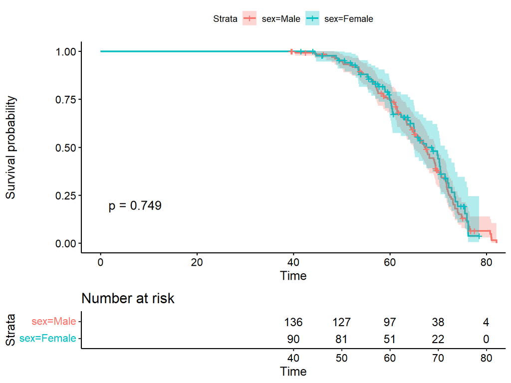

```r
kap_plot_left_trunc
```

After including the subjects’ age in the survival model, we see that the survival curves are almost completely overlapping. In addition, the log-rank test p-value shows that the Kaplan Meier curves are not significantly different.

## Independent Variable Hazard Ratios

Exploratory analyses revealed possible associations between survival status and performance metric variables. The performance metrics (measured both by physician and patient), were included in separate Cox proportional hazards models for each variable (as opposed to including all variables in one model, which might cause over fitting). The survival model accounted for left truncation. The variables Sex, Meal.cal, and wt.loss were included for completeness. Each performance metric was modeled as a ordinal variable, since the scales use discrete values when measured. Each hazard ratio is compared to lowest observed factor level (ph.ecog = 0, ph.karno = 50, pat.karno = 30).

```r
# independent variables to use in univariate coxph models
ind_vars <- c(
  "sex",
  "ph.ecog",
  "ph.karno",
  "pat.karno",
  "meal.cal",
  "wt.loss"
)


# Checking that there are at least 1 observation in each of dead/censored
# in each level of the performance scores
# Since there is only one observation in the censored group in ph.ecog == 3 group,
# This value will be set to NA so it is not included in the coxph analysis

dd %>%
  select(status, one_of(perform_metrics)) %>%
  mutate(across(everything(), as.character)) %>%
  pivot_longer(names(.)[-1]) %>%
  group_by(status, value, name) %>%
  dplyr::summarise(n = sum(!is.na(value))) %>%
  spread(status, n) %>%
  arrange(name) %>%
  filter(is.na(`0`) | is.na(`1`)) %>%
  kable(format = 'html') %>%
  kable_styling()
```

| value | name | 0 | 1 |
| --- | --- | --- | --- |
| 50 | pat.karno | NA | 4 |
| NA | pat.karno | NA | 0 |
| 3 | ph.ecog | NA | 1 |
| NA | ph.ecog | NA | 0 |
| NA | ph.karno | NA | 0 |

```r
test_dd <- dd %>%
  mutate(ph.ecog = factor(ph.ecog, levels = c(0:2)))

hr_cox_ls <- lapply(ind_vars, function(x) {

  # Subset data to only include variables of interest
  sub_dd <- test_dd %>%
    select(status, age, time,  one_of(x))

  # Creating formula
  f <- as.formula(paste0("Surv(time, age+time, status) ~ ", factor(x)))

  # running coxph model
  res <- coxph(f,
               data = sub_dd)

  # testing proportional hazards assumption
  test.ph <- cox.zph(res)

  # Breaking script if assumption not met
  assertthat::assert_that(!any(test.ph$table[,'p'] <= 0.05),
                          msg = "Proportional Hazards Assumption Not met")

  # Getting summary table
  sum <- summary(res)

  # Getting hazard ratio
  hr <- sum$coefficients[, 2]

  # Getting standard error
  se <- sum$coefficients[, 3]

  # calculating upper and lower bounds
  lb <- hr-qnorm(1-0.05/2)*se
  ub <- hr+qnorm(1-0.05/2)*se

  data.frame(
    var = x,
    lvl = names(res$coefficients),
    hr = hr,
    lb = lb,
    ub = ub,
    hr_pval = sum$coefficients[, 5]
    )

})

# Turning list into dataframe, changing labels of the variables and levels
hr_cox_dd <- do.call('rbind', hr_cox_ls) %>%
  mutate(lvl = gsub(paste0(var, collapse = '|'), "",lvl),
         var = ifelse(lvl == '', var, paste(var, lvl, sep = '=')),
         var = factor(var))

# Passing data to a forrest plot, with 95% confidence intervals around hazard ratio estimate
hr_plot <-
  ggplot(data = hr_cox_dd, aes(x = hr, y = var)) +
  geom_errorbar(aes(xmin = lb, xmax = ub)) +
    geom_vline(xintercept = 1, color = 'red', linetype = 'dashed') +
    geom_text(x = 5, aes(label = paste0("p=", round(hr_pval, 2)))) +
    scale_x_continuous(limits = c(-3,6)) +
  xlab("Hazard Ratio (95% CI)") +
  ylab("Variable (level)")
```

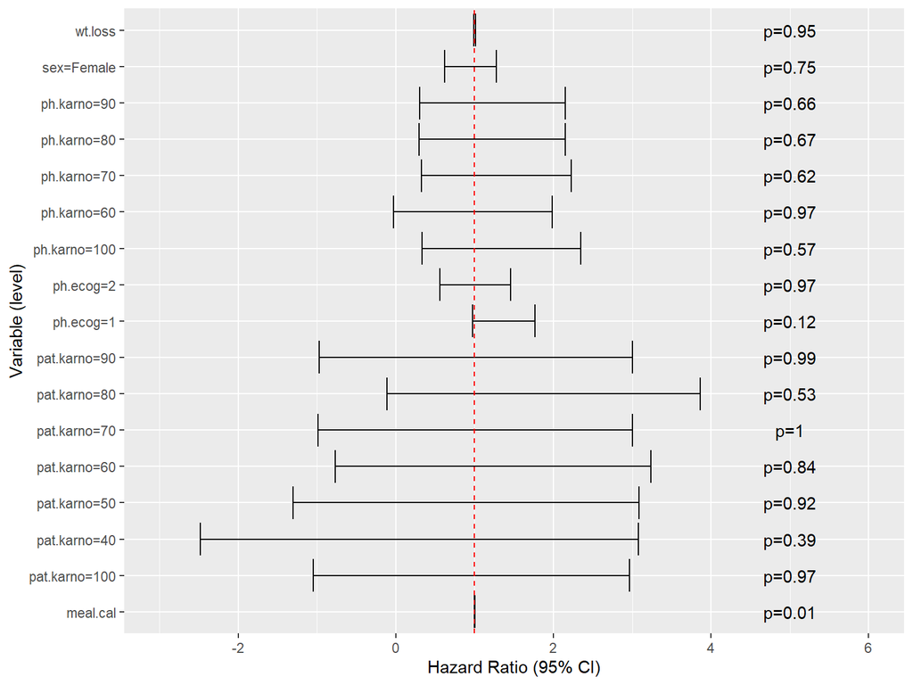

```r
hr_plot
```

In general, 95% confidence intervals around the hazard ratios revealed no significant differences between each level of performance predictor and its respective reference level. There is no evidence here that physician rating is any more related to survival than patient rating. Since the performance scores have many levels, and since the hazard ratio is a comparison to the reference levels of each performance score, additional analyses will be performed to examine overall differences between score groups.

## Survival Curves in performance metrics

Since the hazard ratios only compare to a reference level in each performance metric, survival curves were constructed for each level of the performance metric variables and the score test (equivalent to log-rank test) was used to determine overall differences between survival curves among the performance score variables. The survival model used here accounted for left truncation.

```r
### Log-Rank tests for performance metrics ----
#' Univariate analyses of the different performance metrics showed
         #' that no hazard ratios were significantly different than 1
         #' Log-rank tests will be used to test for overall differences between
         #' survival curves.
         #' Coxph score test will be used to calculate test statistic

         log_rank_test_ls <- lapply(perform_metrics, function(x) {

           # Defining formula
           f <- as.formula(paste0("Surv(time, age+time, status) ~ factor(", x, ")"))

           # Running coxph model
           fit0 <- coxph(f,
                         data = test_dd,
                         # iter = 0,
                         na.action = na.exclude)

           # Testing proportional hazards assumption
           test.ph <- cox.zph(fit0)

           # Breaking script if assumption not met
           assertthat::assert_that(!any(test.ph$table[,'p'] <= 0.05),
                                   msg = "Proportional Hazards Assumption Not met")

           # Getting summary table
           sum <- summary(fit0)

           # Getting p-value from score test
           p_val <- round(sum$sctest[3], 3)

           data.frame(
             var = x,
             p_val = p_val
           )

         })

         # Turning list to a dataframe
         log_rank_test_dd <- do.call('rbind', log_rank_test_ls)

         # Creating plots for each variable, with p-value from test dataframe
         p_1 <- ggsurvplot(survfit(Surv(time,
                                        age+time,
                                        status) ~ ph.ecog, data = test_dd),
                           conf.int = TRUE,
                           pval = log_rank_test_dd$p_val[1])

         p_2 <- ggsurvplot(survfit(Surv(time,
                                        age+time,
                                        status) ~ ph.karno, data = test_dd),
                           conf.int = TRUE,
                           pval = log_rank_test_dd$p_val[2])


         p_3 <- ggsurvplot(survfit(Surv(time,
                                        age+time,
                                        status) ~ pat.karno, data = test_dd),
                           conf.int = TRUE,
                           pval = log_rank_test_dd$p_val[3])
```

### ph.ecog

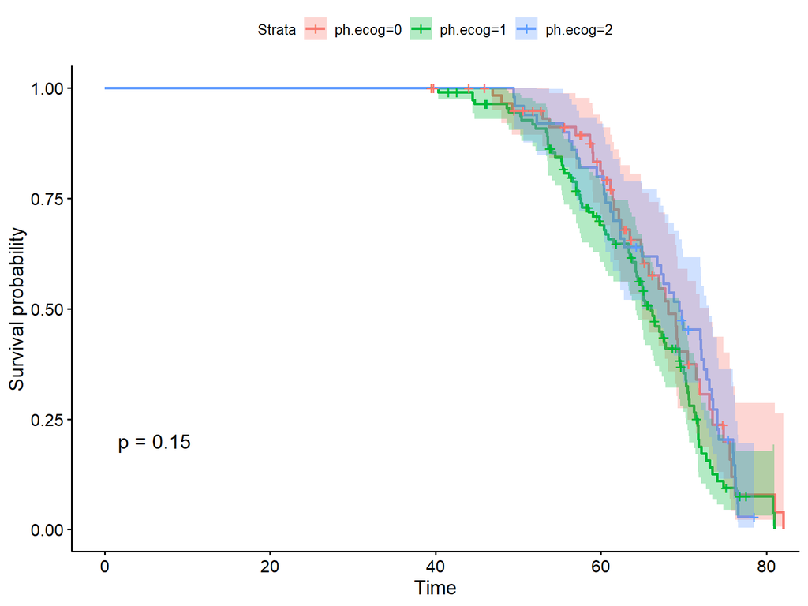

```r
p_1
```

### ph.karno

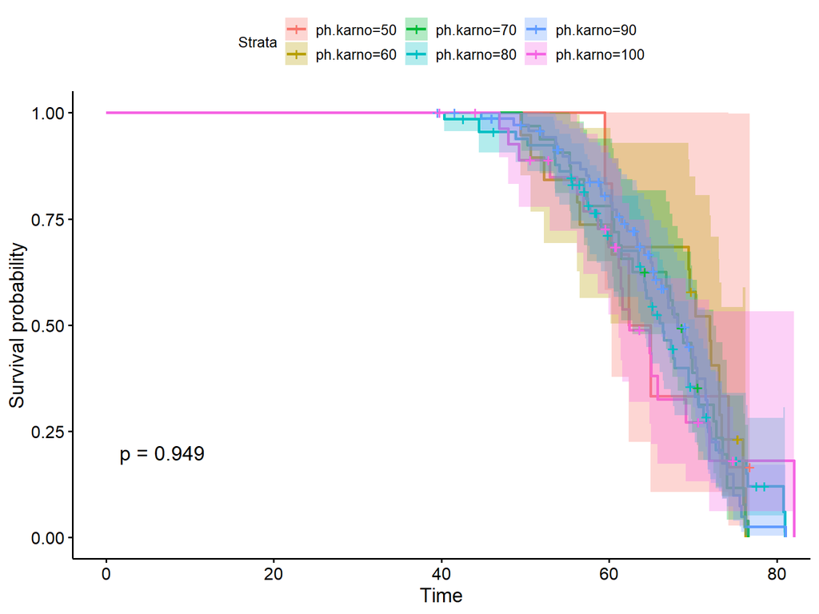

```r
p_2
```

### pat.karno

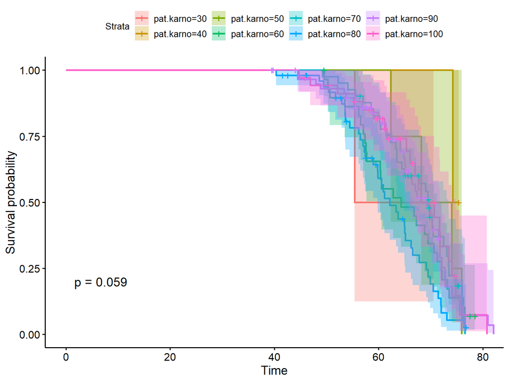

```r
p_3
```

Log-rank tests did not show a difference between survival curves for physician measured or patient measured performance. There was slightly more evidence for differences between groups in the patient scored variable; however, there were many levels and some of the levels had very few observations, which might bias the results.

### Median split differences between survival curves

```r
med_dd <-  dd %>%
  # Selecting variables
  select(status, age, time, all_of(perform_metrics)) %>%
  # Turning performance metrics to numeric
  mutate(across(ph.ecog:pat.karno, as.numeric)) %>%
  pivot_longer(ph.ecog:pat.karno) %>%
  group_by(name) %>%
  # Getting median value by each variable
  dplyr::summarise(med = median(value, na.rm = TRUE)) %>%
  group_by(name) %>%
  # Getting the actual value of the reference level
  mutate(med_val = levels(dd[, name])[med]) %>%
  ungroup()

# Creating test dataframe, with new median split variable
test_dd <- dd %>%
  select(status, age, time, all_of(perform_metrics)) %>%
  mutate(across(ph.ecog:pat.karno, as.numeric)) %>%
  # Creating pseudo-id column to use in pivot_wider
  mutate(id = 1:n()) %>%
  pivot_longer(ph.ecog:pat.karno)  %>%
  # Pulling in medians
  left_join(med_dd, by = c("name")) %>%
  mutate(value = as.numeric(value)) %>%
  # Creating median split variable
  mutate(med_split = case_when(
    value < med ~ paste('Less than', med_val),
    value >= med ~ paste('Greater than or equal to', med_val)
    )) %>%
  select(id, status, age, time, name, med_split) %>%
  pivot_wider(values_from = 'med_split')

# looping over performance metrics, testing difference between variables
log_rank_test_ls <- lapply(perform_metrics, function(x) {

  # Subset data to variables of interest
  sub_dd <- test_dd %>%
    select(id:time, x = all_of(x))

  # Fitting coxph model
  fit0 <- coxph(Surv(time,
                     age+time,
                     status) ~ factor(x),
                data = sub_dd,
                na.action = na.exclude)

  # Testing coxph assumption
  test.ph <- cox.zph(fit0)
  assertthat::assert_that(!any(test.ph$table[,'p'] <= 0.05),
                          msg = "Proportional Hazards Assumption Not met")

  # Getting p-value
  sum <- summary(fit0)
  p_val <- round(sum$sctest[3], 3)

  dat <- data.frame(
    var = x,
    p_val = p_val
  )
  dat
  })

# turning list to dataframe
log_rank_test_dd <- do.call('rbind', log_rank_test_ls)

# Creating plots on the median split variables, with p-value added
p_1_med_split <- ggsurvplot(survfit(Surv(time,
                          age+time,
                          status) ~ ph.ecog,
                     data = test_dd),
                     pval = subset(log_rank_test_dd,
                                   var == "ph.ecog",
                                   p_val)[[1]],
                     conf.int = TRUE)

p_2_med_split <- ggsurvplot(survfit(Surv(time,
                               age+time,
                               status) ~ ph.karno,
                          data = test_dd),
                  pval = subset(log_rank_test_dd,
                                var == "ph.karno",
                                p_val)[[1]],
                  conf.int = TRUE)

p_3_med_split <- ggsurvplot(survfit(Surv(time,
                               age+time,
                               status) ~ pat.karno,
                          data = test_dd),
                  pval = subset(log_rank_test_dd,
                                var == "pat.karno",
                                p_val)[[1]],
                  conf.int = TRUE)



med_dd %>%
  select(name, med_val) %>%
  arrange(name) %>%
  kable(col.names = c("Score Variable", "Median"),
        format = 'latex')
```

Based on the definitions for each performance rating, the median values make intuitive sense to split the data on. For the ECOG score, values below 1 would be asymptomatic, while values >= 1 would be symptomatic. For the Karnofsky score (ph.karno and pat.karno), values below 80 would be below the *Able to carry on normal activity and to work. No special care needed.* condition as specified by: https://www.compassus.com/sparkle-assets/documents/karnofsky_performance_status_scale.pdf

### Ph.ecog

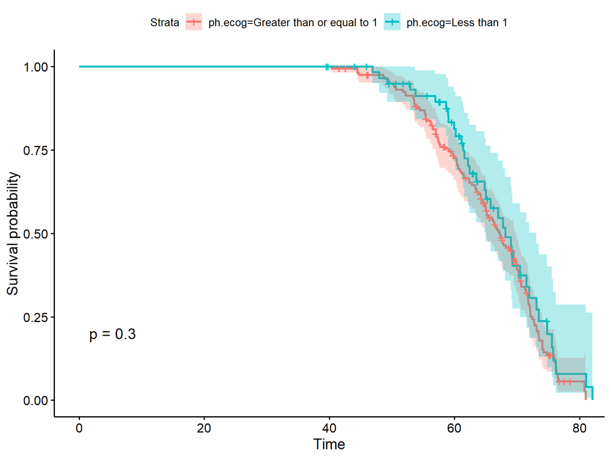

```r
p_1_med_split
```

### ph.karno

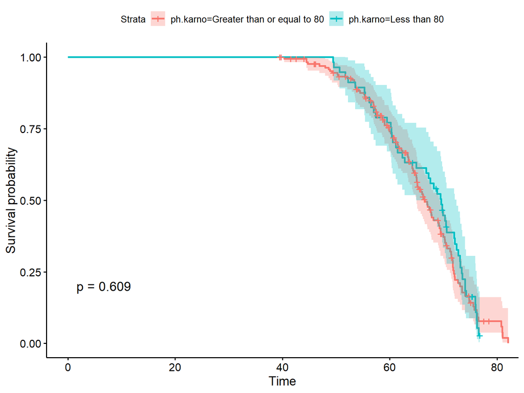

```r
p_2_med_split
```

### pat.karno

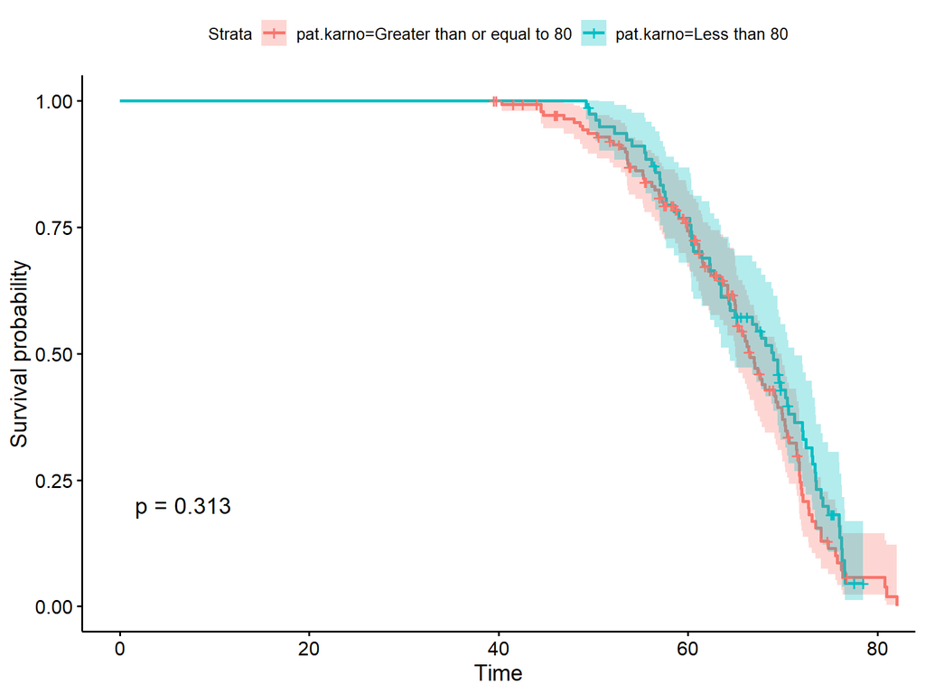

```r
p_3_med_split
```

Based on the log-rank test p-values, as well as the overlapping confidence intervals, there was no difference between median-split survival curves for each performance variable. While there was a lower p-value for pat.karno compared to ph.karno, there is not enough evidence to conclude that physician scoring is any different than patient scoring, in terms of a relationship to survival.